# Residuals Diagnostics and Variation - Week 3

Figure below shows an outlier.

It does not affect the fit that much (see orange and black lines). The outlier is said to `lack influence`.

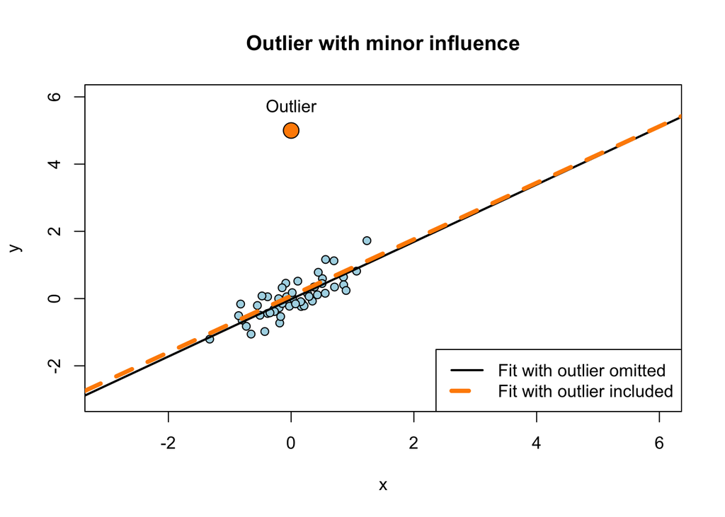

Figure below shows that including the outlier changes the fit. The outlier is said to be `influential`.

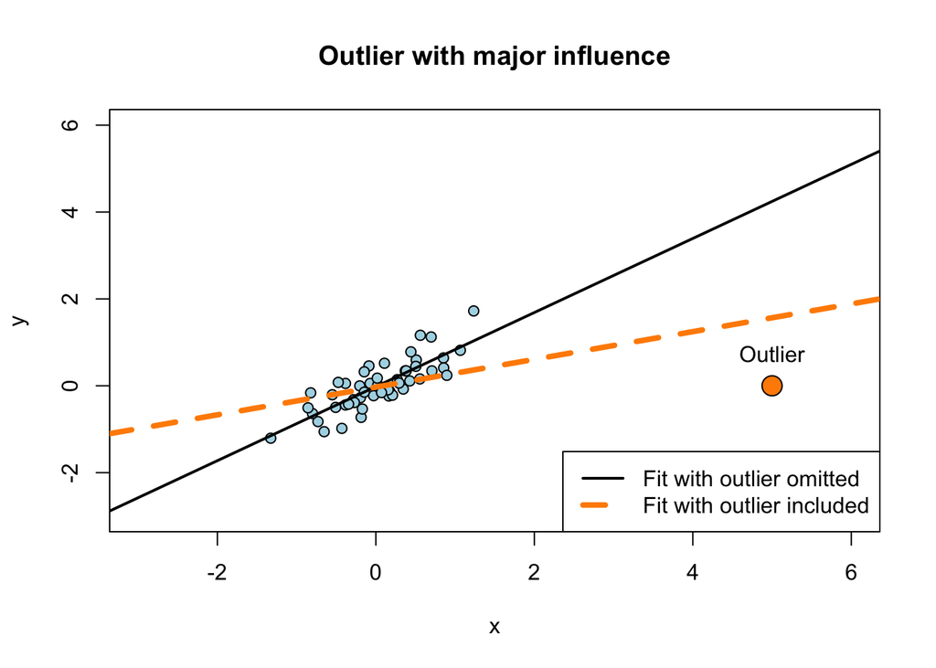

Outilers may represent reals events or may be spurious data.

### Diagnostic plots

#### Display Residuals versus Fitted Values

Residuals should be uncorrelated to the fit, independent and (almost) identicaly distributed with mean zero

More infor about the plot below [here](https://stat.ethz.ch/R-manual/R-devel/library/stats/html/plot.lm.html)

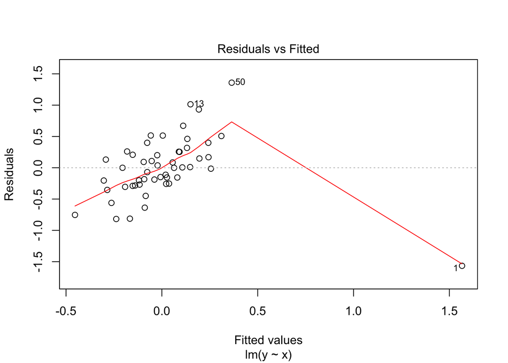

```r
plot(fit, which =1)
```

Residuals don’t seem to be uncorrelated. There’s a linear pattern involving all but one residual and the fit.

From above, the point labelled 1 is the `influential outlier`.

Remove outlier from data

```r
fitno <- lm(y ~ x, out2[-1,])
```

Display new Residuals vc Fitted plot

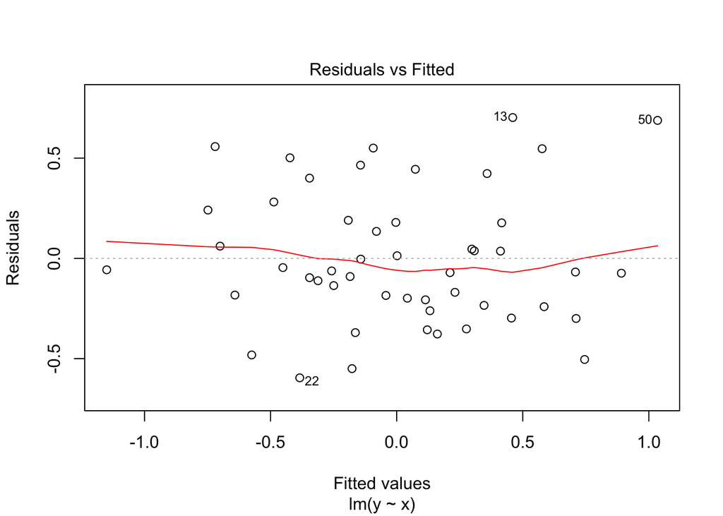

```r
plot(fitno, which =1)
```

Now residuals are independently and (almost) identically distributed with zero mean and uncorrelated to the fit.

- Check the change induced by including the influential first sample:

```r
coef(fit) - coef(fitno)
```

```
(Intercept)           x
-0.01167866 -0.53363019
```

Function `dfbeta` does the equivalent for every sample in the data

```r
head(dfbeta(fit))
```

```
   (Intercept)             x
1 -0.011678662 -0.5336301857
2  0.008636967  0.0045759242
3  0.010323864 -0.0003509441
4  0.003122096 -0.0033664451
5  0.001975966 -0.0008297575
6  0.002230518 -0.0005867041
```

From the above, it is clear that sample 1 has a larger effect (about 100 times of any other point) on the slope (x column) than the other samples shown.

The effect on the intercept is not very distinctive.

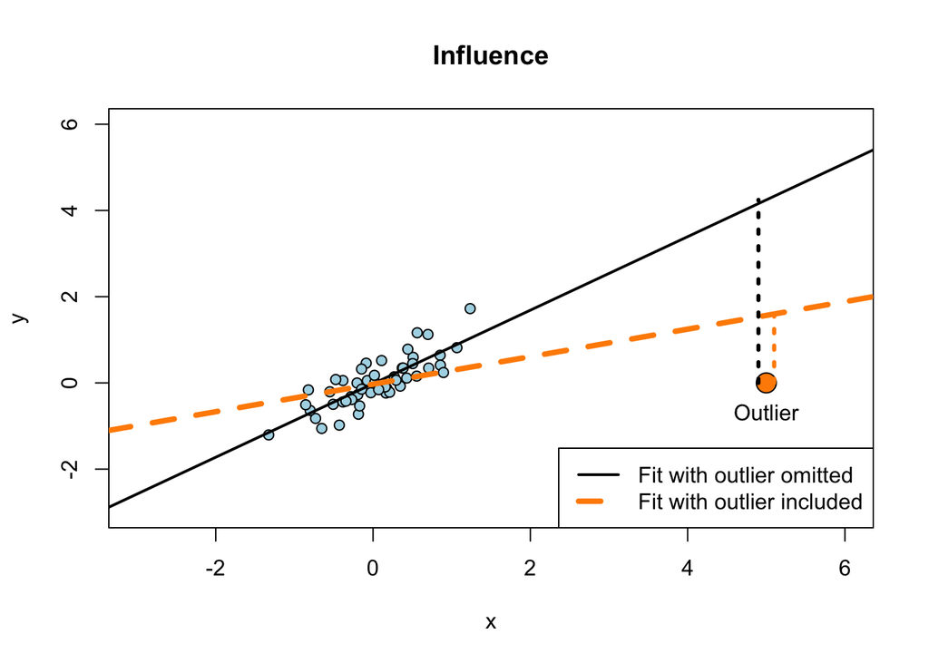

When a sample is included, it pulls the regression closer to itself (orange line). Its residual (difference between actual y value and the predicted y value) is smaller in magnitude than when outlier is omitted.

To compute the influence of an outlier:

```r
head(hatvalues(fit))
```

```
         1          2          3          4          5          6
0.63115474 0.02324999 0.01962520 0.04326099 0.02255531 0.02071441
```

Residuals of individual samples have different variances and these differences can become large in the presence of outliers.

```r
#calculate the sample standard deviation of fit's residual
#it's done by dividing the fit's deviance by the residual DF and taking the sqrt
sigma <- sqrt(deviance(fit)/df.residual(fit))
```

Compute fit’s standardized residual

```r
rstd <- resid(fit)/(sigma * sqrt(1-hatvalues(fit)))
```

Function `rstandard` does the same as above

```r
head(cbind(rstd, rstandard(fit)))
```

```
        rstd
1 -5.1928156 -5.1928156
2  0.9389601  0.9389601
3  1.0450409  1.0450409
4  0.2682743  0.2682743
5  0.1893339  0.1893339
6  0.2186961  0.2186961
```

#### Scale-Location

Shows the square root of standardized residuals against fitted values

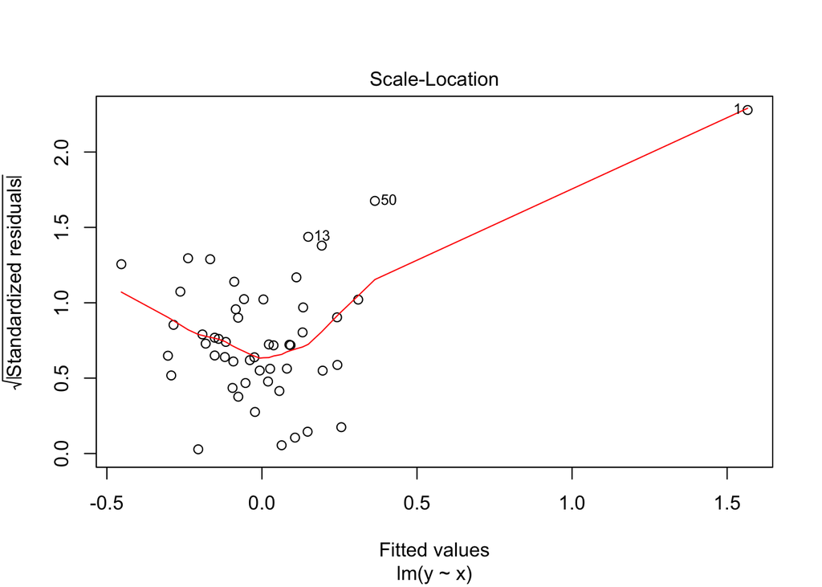

```r
plot(fit, which=3)
```

#### QQ plot of standardized residuals against normal with constant variance

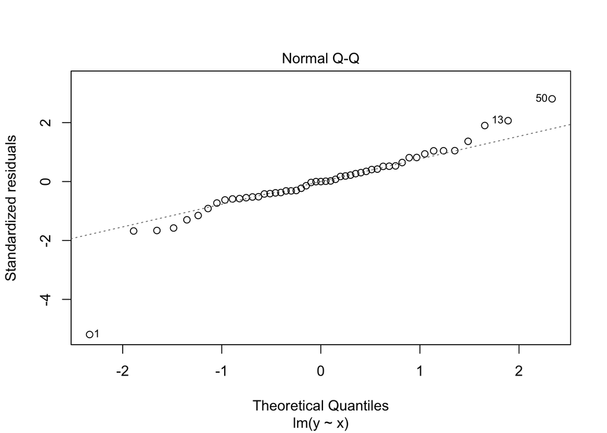

```r
plot(fit, which=2)
```

The outlier’s standardized residual (1) on the NOrmal QQ plot is about -5 standard deviations from the mean

#### Studentized residuals

Estimate the standard deviations of individual residuals using, in addition to individual hat values, the deviance of a model which leaves the associated sample out.

```r
# compute sample sdev of fitno
sigma1 <- sqrt(deviance(fitno)/df.residual(fitno))

# compute studentized residual for the outlier
resid(fit)[1]/(sigma1*sqrt(1-hatvalues(fit)[1]))
```

```
        1
-7.664261
```

The function `rstudent` calculates Studentized residuals for each sample using a procedure equivalent to that was done above

```r
head(rstudent(fit))
```

```
         1          2          3          4          5          6
-7.6642608  0.9378046  1.0460451  0.2657179  0.1874606  0.2165588
```

#### Cook’s distance

It is the sum of squared differences between values fitted with and without a particular sample.

It tells how much a sample changes a model.

```r
#difference between predicted values in fit and fitno
dy <- predict(fit, out2) - predict(fitno, out2)

# compute Cook's distance
sum(dy^2)/(2*sigma^2)
```

```
[1] 23.07105
```

The function `cooks.distance` will calculate Cook’s distance for each sample

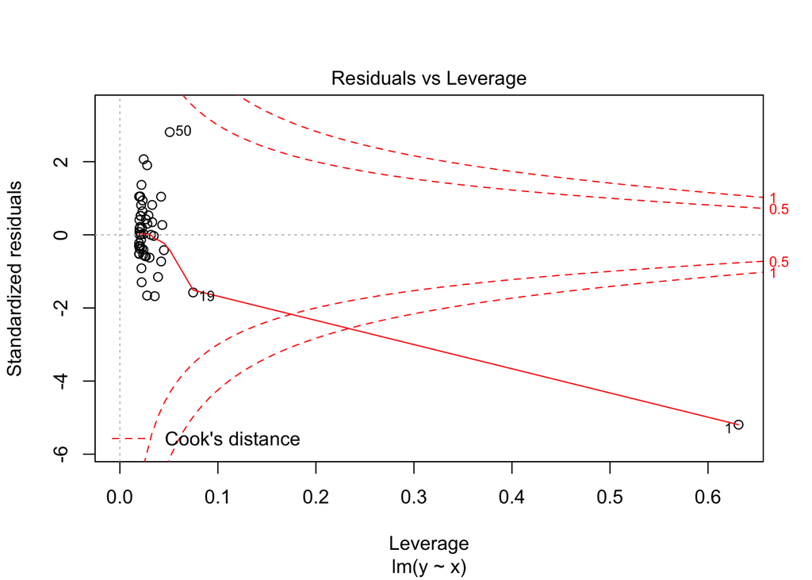

```r
# cooks.distance(fit)[1]
plot(fit, which=5)
```